# Setup: Differential Expression Module

Ally Hawkins for the Data Lab

2022-12-08

## Setup and some initial exploration

In this notebook we are planning to start with an object that has already been integrated. This integrated object has a column that indicates the original batch (currently labeled `batch` but will be renamed to “sample”) and a column that indicates cell types (`celltype`) in the `colData`.

We can also grab any other additional sample-level metadata from the metadata file for this dataset. We can use that to help identify groups of interest for differential expression.

In this first section, we explore the integrated object and identify libraries that would be good to use in setting up differential expression.

```r
set.seed(2022)

library(magrittr)
library(SingleCellExperiment)
library(ggplot2)
```

The merged and integrated datasets are available on S3 right now (`s3://sc-data-integration/scpca`), but after deciding what exactly we will use as input here, we will create the proper setup scripts and move the data to the server starting with the individual SCE objects used to create the integrated dataset.

```r
# set up file paths and read in combined SCE and integrated SCE
data_dir <- file.path("..", "setup", "rms-integration")

combined_sce_file <- file.path(data_dir, "dge", "SCPCP000005_merged_sce.rds")
combined_sce <- readr::read_rds(combined_sce_file)


integrated_sce_file <- file.path(data_dir, "dge", "SCPCP000005_integrated_fastmnn_sce.rds")
integrated_sce <- readr::read_rds(integrated_sce_file)
```

```r
# put the integrated PCA and UMAP into the combined object so all the data is together
reducedDim(combined_sce, "fastMNN_PCA") <- reducedDim(integrated_sce, "fastmnn_PCA")
reducedDim(combined_sce, "fastMNN_UMAP") <- reducedDim(integrated_sce, "fastmnn_UMAP")
reducedDimNames(combined_sce)
```

```
[1] "PCA"          "UMAP"         "fastMNN_PCA"  "fastMNN_UMAP"
```

```r
# file path to sample level metadata
sample_metadata_file <- file.path(data_dir, "rms_sample_metadata.tsv")

# read in sample level metadata to use for DE
sample_metadata <- readr::read_tsv(sample_metadata_file)
```

Let’s take the sample metadata file and add in the metadata to the `colData` of the combined SCE object. While doing this we can also do some modifying of the columns in the `colData`, such as creating a `celltype_broad` and `celltype_fine` column to use for plotting.

```r
# collapse cell types
coldata_df <- colData(combined_sce) %>%
  as.data.frame() %>%
  tibble::rownames_to_column("cell_id") %>%
  # remove any of the subtypes to create new cell type column
  dplyr::mutate(celltype_broad = stringr::str_remove(celltype, "-[ABCD]$"),
                celltype_fine = celltype) %>%
  # merge with sample metadata
  dplyr::left_join(sample_metadata, by = c("batch" = "library_id"))

# add back to sce
colData(combined_sce) <- DataFrame(coldata_df, row.names = coldata_df$cell_id)
```

Let’s just do some initial exploration of the integrated dataset that we are working with.

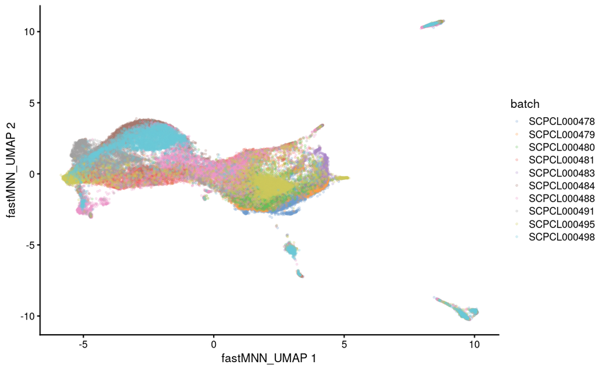

```r
# UMAP to show cell type and integration
scater::plotReducedDim(combined_sce,
                       dimred = "fastMNN_UMAP",
                       colour_by = "batch",
                       point_size= 0.5,
                       point_alpha = 0.2)
```

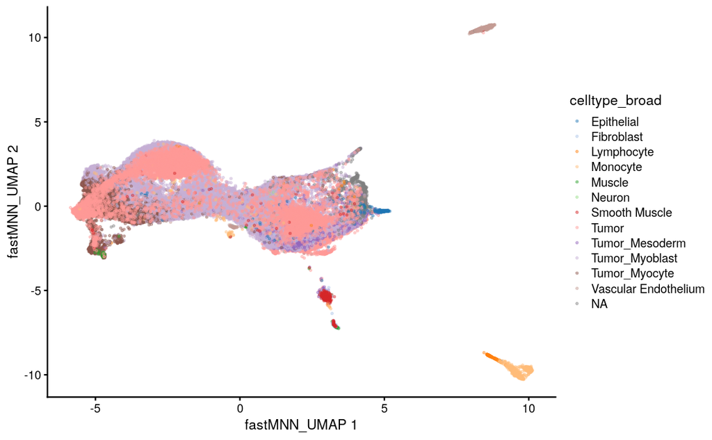

```r
# show cell types in the integrated dataset
scater::plotReducedDim(combined_sce,
                       dimred = "fastMNN_UMAP",
                       colour_by = "celltype_broad",
                       point_size= 0.5,
                       point_alpha = 0.4)
```

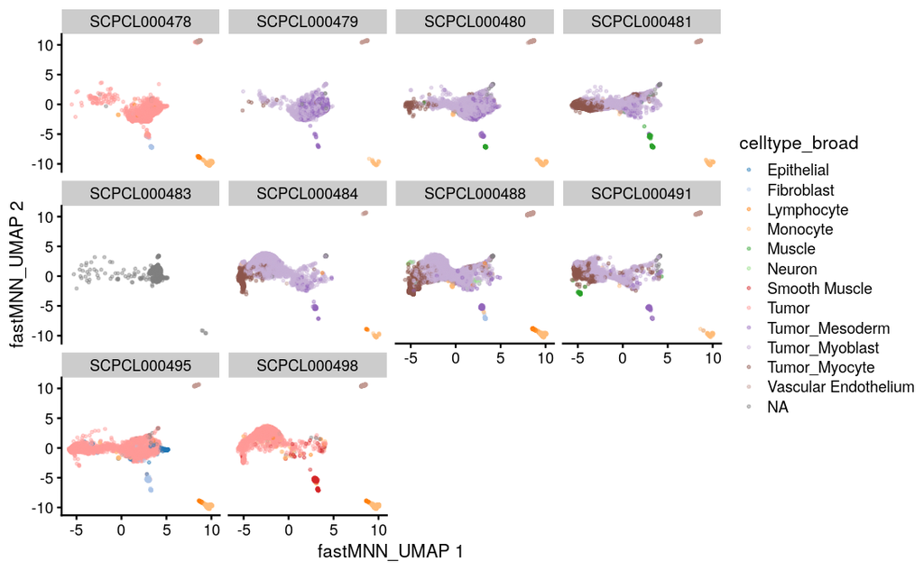

```r
# facet the UMAP by sample to show the distribution of cell types across each sample
scater::plotReducedDim(combined_sce,
                       dimred = "fastMNN_UMAP",
                       colour_by = "celltype_broad",
                       point_size= 0.5,
                       point_alpha = 0.4) +
  facet_wrap(~ combined_sce$batch, nrow = 3)
```

Looking at this plot lets us know which cell types belong to which sample and can help us pick which libraries we might want to consider for differential expression. From this we see that 6 of the libraries show a split between `Tumor_Mesoderm`, `Tumor_Myoblast` and `Tumor_Myocyte`. 3 libraries are mostly `Tumor` and they probably weren’t able to be classified into sub types. Then 1 library has what appears to be all `NA`. Let’s just look at the libraries that have myoblast, mesoderm, and myocytes and see if we can do some differential expression between those libraries.

## Set up of dataset to use for integration

```r
# define libraries to keep
scpca_library_ids <- c(
  "SCPCL000479",
  "SCPCL000480",
  "SCPCL000481",
  "SCPCL000484",
  "SCPCL000488",
  "SCPCL000491"
)

# subset sce to only contain batches with library IDs of interest
batches_to_keep <- combined_sce$batch %in% scpca_library_ids
rms_sce <- combined_sce[,batches_to_keep]
```

Let’s make some of the same plots above and show the distribution of cell types.

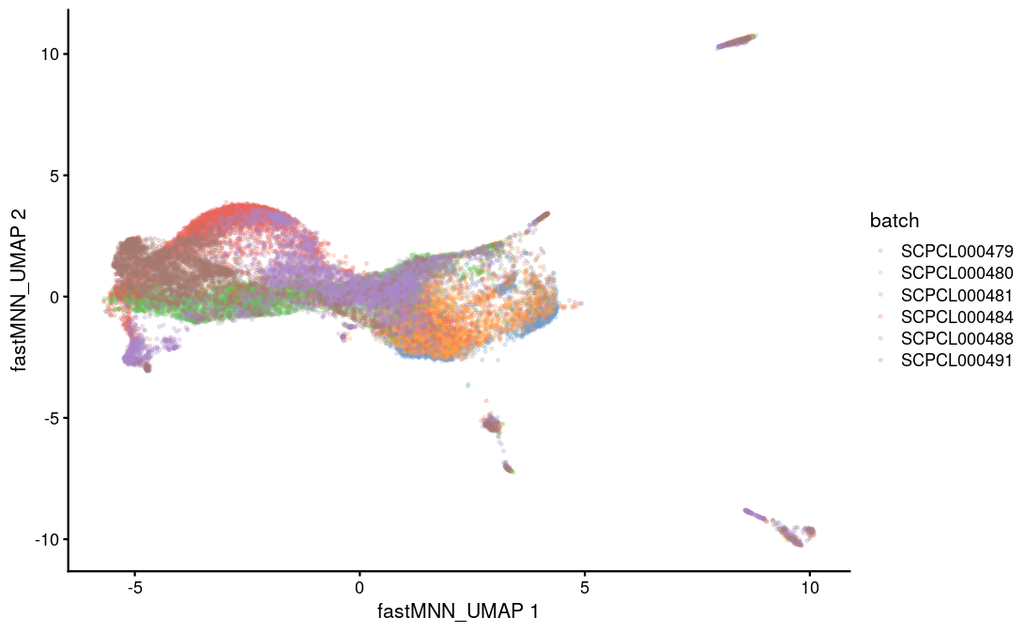

```r
# UMAP to show cell type and integration
scater::plotReducedDim(rms_sce,
                       dimred = "fastMNN_UMAP",
                       colour_by = "batch",
                       point_size= 0.5,
                       point_alpha = 0.2)
```

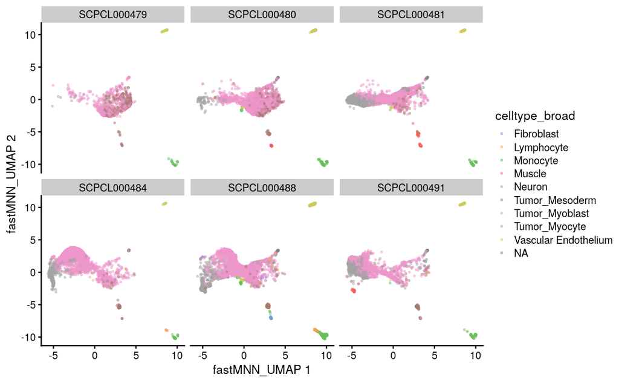

```r
scater::plotReducedDim(rms_sce,
                       dimred = "fastMNN_UMAP",
                       colour_by = "celltype_broad",
                       point_size= 0.5,
                       point_alpha = 0.4) +
  facet_wrap(~ rms_sce$batch)
```

It looks like the pink cells, or the `Tumor_Myoblast` are the most dominant cell type across the libraries. This might be an interesting group to start with for differential expression. We can confirm this by looking at the total numbers of cells in each cell type.

```r
# can also print out a summary of the cell types across each library
colData(rms_sce) %>%
  as.data.frame() %>%
  dplyr::count(batch, celltype_broad) %>%
  dplyr::group_split(batch)
```

```
<list_of<
  tbl_df<
    batch         : character
    celltype_broad: character
    n             : integer
  >
>[6]>
[[1]]
```

| batch | celltype_broad | n |
| --- | --- | --- |
| SCPCL000479 | Monocyte | 21 |
| SCPCL000479 | Tumor_Mesoderm | 837 |
| SCPCL000479 | Tumor_Myoblast | 1242 |
| SCPCL000479 | Tumor_Myocyte | 17 |
| SCPCL000479 | Vascular Endothelium | 26 |
| SCPCL000479 | NA | 15 |

| batch | celltype_broad | n |
| --- | --- | --- |
| SCPCL000480 | Monocyte | 76 |
| SCPCL000480 | Muscle | 80 |
| SCPCL000480 | Tumor_Mesoderm | 850 |
| SCPCL000480 | Tumor_Myoblast | 3257 |
| SCPCL000480 | Tumor_Myocyte | 85 |
| SCPCL000480 | Vascular Endothelium | 119 |
| SCPCL000480 | NA | 33 |

| batch | celltype_broad | n |
| --- | --- | --- |
| SCPCL000481 | Monocyte | 49 |
| SCPCL000481 | Muscle | 94 |
| SCPCL000481 | Tumor_Mesoderm | 181 |
| SCPCL000481 | Tumor_Myoblast | 3227 |
| SCPCL000481 | Tumor_Myocyte | 1635 |
| SCPCL000481 | Vascular Endothelium | 59 |
| SCPCL000481 | NA | 30 |

| batch | celltype_broad | n |
| --- | --- | --- |
| SCPCL000484 | Lymphocyte | 11 |
| SCPCL000484 | Monocyte | 43 |
| SCPCL000484 | Tumor_Mesoderm | 85 |
| SCPCL000484 | Tumor_Myoblast | 4137 |
| SCPCL000484 | Tumor_Myocyte | 598 |
| SCPCL000484 | Vascular Endothelium | 13 |
| SCPCL000484 | NA | 25 |

| batch | celltype_broad | n |
| --- | --- | --- |
| SCPCL000488 | Fibroblast | 62 |
| SCPCL000488 | Lymphocyte | 127 |
| SCPCL000488 | Monocyte | 195 |
| SCPCL000488 | Neuron | 89 |
| SCPCL000488 | Tumor_Mesoderm | 228 |
| SCPCL000488 | Tumor_Myoblast | 3717 |
| SCPCL000488 | Tumor_Myocyte | 1183 |
| SCPCL000488 | Vascular Endothelium | 269 |
| SCPCL000488 | NA | 78 |

| batch | celltype_broad | n |
| --- | --- | --- |
| SCPCL000491 | Monocyte | 41 |
| SCPCL000491 | Muscle | 38 |
| SCPCL000491 | Tumor_Mesoderm | 99 |
| SCPCL000491 | Tumor_Myoblast | 2353 |
| SCPCL000491 | Tumor_Myocyte | 1051 |
| SCPCL000491 | Vascular Endothelium | 67 |
| SCPCL000491 | NA | 102 |

```
NA
```

`Tumor_Myoblast` is definitely the top represented cell type across the libraries. So we want to look at myoblasts across our libraries and see if there are any changes in the myoblast population between samples of different types. To do this, we should probably look at our sample metadata to see what types of samples we are looking at.

```r
# Let's look at some of the clinical sample metadata that we have
table(rms_sce$diagnosis) # everything is RMS
table(rms_sce$subdiagnosis) # sample is split between ERMS and ARMS

# how many of each, 3 of each subdiagnosis, that's enough replicates so let's compare!
colData(rms_sce) %>%
  as.data.frame() %>%
  dplyr::count(batch, subdiagnosis)
```

[output not shown]

It looks like we have three samples that are from ARMS patients and three samples that are from ERMS patients.

A good question we could ask is if there are differences in gene expression patterns in the Myoblast population between ARMS and ERMS patients. If we want to ask that question, then we need to have replicates, preferably at least 3 samples for each type of patient, which we do!

Let’s go ahead and try it!

## Differential Expression between conditions

### Pseudo-bulking

Before we can do DE analysis to compare the gene expression profiles of myoblasts in ARMS vs. ERMS patients, we will need to “pseudo-bulk” the gene counts. Pseudo-bulking creates a new counts matrix that contains the total counts across all cells of a given label (e.g. cell type) for each sample. This allows us to use single-cell resolution to define the labels and sum gene counts across groups of cells containing the same label, and avoids counting each cell as its own replicate.

Below are a few reasons why pseudo-bulking is helpful:

- Produces larger counts which are more amenable to standard normalization and differential expression methods used by bulk RNA-sequencing.
- Collapses gene expression counts by sample, so that samples, rather than cells, represent replicates.
- Masks variance within a sample to highlight variance across samples.

Let’s start with the simple comparison of looking at one cell type and comparing across ERMS and ARMS subtypes. When we do this, we will first want to pseudo-bulk our dataset to group our cells by cell type and by sample. Then we can subset the pseudo-bulked dataset to just contain our cell type of interest before proceeding.

```r
pseudobulked_sce
```

```
class: SingleCellExperiment
dim: 573 37
metadata(202): salmon_version-SCPCL000478 reference_index-SCPCL000478 ...
  variable_genes subset_hvg
assays(1): counts
rownames(573): ENSG00000278996 ENSG00000150672 ... ENSG00000135932
  ENSG00000079805
rowData names(30): gene_symbol-SCPCL000478 mean-SCPCL000478 ... mean-SCPCL000498
  detected-SCPCL000498
colnames(37): Fibroblast-SCPCL000488 Lymphocyte-SCPCL000484 ... Vascular
  Endothelium-SCPCL000488 Vascular Endothelium-SCPCL000491
colData names(22): cell_id sum ... batch ncells
reducedDimNames(4): PCA UMAP fastMNN_PCA fastMNN_UMAP
mainExpName: NULL
altExpNames(0):
```

```r
# only 37 columns in the counts assay
counts(pseudobulked_sce)[1:10, 1:10]
```

```
                Fibroblast-SCPCL000488 Lymphocyte-SCPCL000484 Lymphocyte-SCPCL000488
ENSG00000278996                     79                      0                    271
ENSG00000150672                    121                      9                     50
ENSG00000157168                      9                      4                     33
ENSG00000161671                     56                     38                    194
ENSG00000258399                     96                     28                    232
ENSG00000185532                   1428                     33                     76
ENSG00000157445                     52                     28                     93
ENSG00000198947                    415                      1                    170
ENSG00000245532                    631                      4                    458
ENSG00000155974                      8                     26                     51
                Monocyte-SCPCL000479 Monocyte-SCPCL000480 Monocyte-SCPCL000481
ENSG00000278996                   51                  224                   76
ENSG00000150672                    6                   23                  430
ENSG00000157168                    0                   14                  342
ENSG00000161671                    3                   14                   11
ENSG00000258399                    4                    6                   34
ENSG00000185532                    6                   72                  140
ENSG00000157445                   22                    2                    0
ENSG00000198947                    4                    4                   38
ENSG00000245532                   67                  358                  471
ENSG00000155974                    2                   15                   22
                Monocyte-SCPCL000484 Monocyte-SCPCL000488 Monocyte-SCPCL000491
ENSG00000278996                   43                  457                  262
ENSG00000150672                   34                  235                  455
ENSG00000157168                    2                  112                    1
ENSG00000161671                  226                  696                   85
ENSG00000258399                   33                  813                    0
ENSG00000185532                   13                  287                   11
ENSG00000157445                   16                  265                   41
ENSG00000198947                   18                  469                   25
ENSG00000245532                  265                 2513                  699
ENSG00000155974                    9                   96                   32
                Muscle-SCPCL000480
ENSG00000278996                209
ENSG00000150672                 54
ENSG00000157168                 33
ENSG00000161671                 53
ENSG00000258399                 55
ENSG00000185532               1208
ENSG00000157445                  2
ENSG00000198947                 44
ENSG00000245532                184
ENSG00000155974                 23
```

Let’s take a look at what the `colData` now looks like in the pseudo-bulked SCE object.

```r
# note the new addition of the column with number of cells per group
colData(pseudobulked_sce)
```

```
DataFrame with 37 rows and 22 columns
                                     cell_id       sum  detected subsets_mito_sum
                                 <character> <numeric> <integer>        <numeric>
Fibroblast-SCPCL000488                    NA        NA        NA               NA
Lymphocyte-SCPCL000484                    NA        NA        NA               NA
Lymphocyte-SCPCL000488                    NA        NA        NA               NA
Monocyte-SCPCL000479                      NA        NA        NA               NA
Monocyte-SCPCL000480                      NA        NA        NA               NA
...                                      ...       ...       ...              ...
Vascular Endothelium-SCPCL000480          NA        NA        NA               NA
Vascular Endothelium-SCPCL000481          NA        NA        NA               NA
Vascular Endothelium-SCPCL000484          NA        NA        NA               NA
Vascular Endothelium-SCPCL000488          NA        NA        NA               NA
Vascular Endothelium-SCPCL000491          NA        NA        NA               NA
                                 subsets_mito_detected subsets_mito_percent
                                             <integer>            <numeric>
Fibroblast-SCPCL000488                              NA                   NA
Lymphocyte-SCPCL000484                              NA                   NA
Lymphocyte-SCPCL000488                              NA                   NA
Monocyte-SCPCL000479                                NA                   NA
Monocyte-SCPCL000480                                NA                   NA
...                                                ...                  ...
Vascular Endothelium-SCPCL000480                    NA                   NA
Vascular Endothelium-SCPCL000481                    NA                   NA
Vascular Endothelium-SCPCL000484                    NA                   NA
Vascular Endothelium-SCPCL000488                    NA                   NA
Vascular Endothelium-SCPCL000491                    NA                   NA
                                             celltype       batch       celltype_broad
                                             <factor> <character>          <character>
Fibroblast-SCPCL000488                     Fibroblast SCPCL000488           Fibroblast
Lymphocyte-SCPCL000484                     Lymphocyte SCPCL000484           Lymphocyte
Lymphocyte-SCPCL000488                     Lymphocyte SCPCL000488           Lymphocyte
Monocyte-SCPCL000479                       Monocyte   SCPCL000479             Monocyte
Monocyte-SCPCL000480                       Monocyte   SCPCL000480             Monocyte
...                                               ...         ...                  ...
Vascular Endothelium-SCPCL000480 Vascular Endothelium SCPCL000480 Vascular Endothelium
Vascular Endothelium-SCPCL000481 Vascular Endothelium SCPCL000481 Vascular Endothelium
Vascular Endothelium-SCPCL000484 Vascular Endothelium SCPCL000484 Vascular Endothelium
Vascular Endothelium-SCPCL000488 Vascular Endothelium SCPCL000488 Vascular Endothelium
Vascular Endothelium-SCPCL000491 Vascular Endothelium SCPCL000491 Vascular Endothelium
```

[output cut: 37 more lines]

```
Vascular Endothelium-SCPCL000488 Alveolar rhabdomyosa..             Calf Initial diagnosis
Vascular Endothelium-SCPCL000491 Alveolar rhabdomyosa..            Chest        Recurrence
                                       celltype_broad       batch    ncells
                                          <character> <character> <integer>
Fibroblast-SCPCL000488                     Fibroblast SCPCL000488        62
Lymphocyte-SCPCL000484                     Lymphocyte SCPCL000484        11
Lymphocyte-SCPCL000488                     Lymphocyte SCPCL000488       127
Monocyte-SCPCL000479                         Monocyte SCPCL000479        21
Monocyte-SCPCL000480                         Monocyte SCPCL000480        76
...                                               ...         ...       ...
Vascular Endothelium-SCPCL000480 Vascular Endothelium SCPCL000480       119
Vascular Endothelium-SCPCL000481 Vascular Endothelium SCPCL000481        59
Vascular Endothelium-SCPCL000484 Vascular Endothelium SCPCL000484        13
Vascular Endothelium-SCPCL000488 Vascular Endothelium SCPCL000488       269
Vascular Endothelium-SCPCL000491 Vascular Endothelium SCPCL000491        67
```

Before we can perform DGE analysis, we want to do some quality control like filtering out any groups in the pseudo-bulked dataset that may have a low number of cells.

```r
# filter by number of cells
filtered_pseudobulked_sce <- pseudobulked_sce[, pseudobulked_sce$ncells >= 10]
```

We also want to filter out any genes that may be lowly expressed in our pseudo-bulked dataset.

```r
# filter out genes that might be lowly expressed using filterbyExpr in `edgeR`
# provide sample groups from SCE to determine minimum sample size that genes should be expressed in
# we are grouping samples as ERMS vs. ARMS so use subdiagnosis
genes_filter <- edgeR::filterByExpr(filtered_pseudobulked_sce,
                                     group = filtered_pseudobulked_sce$subdiagnosis)
filtered_pseudobulked_sce <- filtered_pseudobulked_sce[genes_filter,]

# looks like this doesn't actually filter anything though, but we probably want to keep this step in? it seems important
```

Maybe we should explore changing defaults in instruction? Adding the defaults here for future reference.

- `min.count = 10`: Minimum count required for at least some samples.
- `min.total.count = 15`: Minimum total count required.
- `large.n = 10`: Number of samples per group that is considered to be “large”.
- `min.prop = 0.7`: Minimum proportion of samples in the smallest group that express the gene.

The last filtering will be to filter to just the sub type of cells that we are interested in.

```r
tumor_myoblast_sce <- filtered_pseudobulked_sce[, filtered_pseudobulked_sce$celltype_broad == "Tumor_Myoblast"]
table(tumor_myoblast_sce$celltype_broad)
```

```
Tumor_Myoblast
             6
```

We should now see that there are only 6 samples left that all have the cell type `Tumor_Myoblast`.

### Perform differential expression with `edgeR`

Note that at this point we can treat our data set like bulk RNA-seq samples where each library is a sample and use the same methods we would use for bulk, such as `edgeR` and `DESeq2`. First let’s try and do some DE analysis with `edgeR`.

```r
dge_list <- edgeR::DGEList(counts(tumor_myoblast_sce),
                    samples = colData(tumor_myoblast_sce))

# make column names equal to batch ids, helpful for plotting later
colnames(dge_list) <- dge_list$samples$batch
dge_list
```

```
An object of class "DGEList"
$counts
                SCPCL000479 SCPCL000480 SCPCL000481 SCPCL000484 SCPCL000488 SCPCL000491
ENSG00000278996        3328        3214        3469        5496        8004       13768
ENSG00000150672        2772        7808      139767        7272        7892       44982
ENSG00000157168        3619        5494       87515        2693        6692        2034
ENSG00000161671         536        4758        4590       40668       31449       21699
ENSG00000258399        5464        4875        8841       16016       49919         218
568 more rows ...

$samples
```

|  | group | lib.size | norm.factors | cell_id | sum | detected | subsets_mito_sum | subsets_mito_detected | subsets_mito_percent | celltype | batch | celltype_broad | celltype_fine | project_id | submitter | sample_id | diagnosis | technology | seq_unit | subdiagnosis | tissue_location | disease_timing | celltype_broad.1 | batch.1 | ncells |
| --- | --- | --- | --- | --- | --- | --- | --- | --- | --- | --- | --- | --- | --- | --- | --- | --- | --- | --- | --- | --- | --- | --- | --- | --- | --- |
| SCPCL000479 | 1 | 1225866 | 1 | NA | NA | NA | NA | NA | NA | NA | SCPCL000479 | Tumor_Myoblast | NA | SCPCP000005 | dyer_chen | SCPCS000253 | Rhabdomyosarcoma | 10Xv3 | nucleus | Embryonal rhabdomyosarcoma | Prostate | Recurrence | Tumor_Myoblast | SCPCL000479 | 1242 |
| SCPCL000480 | 1 | 1740587 | 1 | NA | NA | NA | NA | NA | NA | NA | SCPCL000480 | Tumor_Myoblast | NA | SCPCP000005 | dyer_chen | SCPCS000254 | Rhabdomyosarcoma | 10Xv3 | nucleus | Embryonal rhabdomyosarcoma | Prostate/bladder | Recurrence | Tumor_Myoblast | SCPCL000480 | 3257 |
| SCPCL000481 | 1 | 3660473 | 1 | NA | NA | NA | NA | NA | NA | NA | SCPCL000481 | Tumor_Myoblast | NA | SCPCP000005 | dyer_chen | SCPCS000255 | Rhabdomyosarcoma | 10Xv3 | nucleus | Embryonal rhabdomyosarcoma | Pelvis | Recurrence | Tumor_Myoblast | SCPCL000481 | 3227 |
| SCPCL000484 | 1 | 2002366 | 1 | NA | NA | NA | NA | NA | NA | NA | SCPCL000484 | Tumor_Myoblast | NA | SCPCP000005 | dyer_chen | SCPCS000258 | Rhabdomyosarcoma | 10Xv3 | nucleus | Alveolar rhabdomyosarcoma | Thigh | Initial diagnosis | Tumor_Myoblast | SCPCL000484 | 4137 |
| SCPCL000488 | 1 | 3949222 | 1 | NA | NA | NA | NA | NA | NA | NA | SCPCL000488 | Tumor_Myoblast | NA | SCPCP000005 | dyer_chen | SCPCS000262 | Rhabdomyosarcoma | 10Xv3 | nucleus | Alveolar rhabdomyosarcoma | Calf | Initial diagnosis | Tumor_Myoblast | SCPCL000488 | 3717 |
| SCPCL000491 | 1 | 6688841 | 1 | NA | NA | NA | NA | NA | NA | NA | SCPCL000491 | Tumor_Myoblast | NA | SCPCP000005 | dyer_chen | SCPCS000265 | Rhabdomyosarcoma | 10Xv3 | nucleus | Alveolar rhabdomyosarcoma | Chest | Recurrence | Tumor_Myoblast | SCPCL000491 | 2353 |

```
NA
```

Now we need to normalize these counts!

Use the trimmed mean of M-values method to compute normalization factors. Counts are now large enough to apply bulk normalization methods rather than the deconvolution method that was used on individual libraries.

```r
# compute some normalization factors
dge_list <- edgeR::calcNormFactors(dge_list)
# should now see a new column, `norm.factors`
dge_list$samples
```

|  | group | lib.size | norm.factors | cell_id | sum | detected | subsets_mito_sum | subsets_mito_detected | subsets_mito_percent | celltype | batch | celltype_broad | celltype_fine | project_id | submitter | sample_id | diagnosis | technology | seq_unit | subdiagnosis | tissue_location | disease_timing | celltype_broad.1 | batch.1 | ncells |
| --- | --- | --- | --- | --- | --- | --- | --- | --- | --- | --- | --- | --- | --- | --- | --- | --- | --- | --- | --- | --- | --- | --- | --- | --- | --- |
| SCPCL000479 | 1 | 1225866 | 1.1254073 | NA | NA | NA | NA | NA | NA | NA | SCPCL000479 | Tumor_Myoblast | NA | SCPCP000005 | dyer_chen | SCPCS000253 | Rhabdomyosarcoma | 10Xv3 | nucleus | Embryonal rhabdomyosarcoma | Prostate | Recurrence | Tumor_Myoblast | SCPCL000479 | 1242 |
| SCPCL000480 | 1 | 1740587 | 1.0976780 | NA | NA | NA | NA | NA | NA | NA | SCPCL000480 | Tumor_Myoblast | NA | SCPCP000005 | dyer_chen | SCPCS000254 | Rhabdomyosarcoma | 10Xv3 | nucleus | Embryonal rhabdomyosarcoma | Prostate/bladder | Recurrence | Tumor_Myoblast | SCPCL000480 | 3257 |
| SCPCL000481 | 1 | 3660473 | 0.9431397 | NA | NA | NA | NA | NA | NA | NA | SCPCL000481 | Tumor_Myoblast | NA | SCPCP000005 | dyer_chen | SCPCS000255 | Rhabdomyosarcoma | 10Xv3 | nucleus | Embryonal rhabdomyosarcoma | Pelvis | Recurrence | Tumor_Myoblast | SCPCL000481 | 3227 |
| SCPCL000484 | 1 | 2002366 | 0.9458181 | NA | NA | NA | NA | NA | NA | NA | SCPCL000484 | Tumor_Myoblast | NA | SCPCP000005 | dyer_chen | SCPCS000258 | Rhabdomyosarcoma | 10Xv3 | nucleus | Alveolar rhabdomyosarcoma | Thigh | Initial diagnosis | Tumor_Myoblast | SCPCL000484 | 4137 |
| SCPCL000488 | 1 | 3949222 | 0.9431212 | NA | NA | NA | NA | NA | NA | NA | SCPCL000488 | Tumor_Myoblast | NA | SCPCP000005 | dyer_chen | SCPCS000262 | Rhabdomyosarcoma | 10Xv3 | nucleus | Alveolar rhabdomyosarcoma | Calf | Initial diagnosis | Tumor_Myoblast | SCPCL000488 | 3717 |
| SCPCL000491 | 1 | 6688841 | 0.9621974 | NA | NA | NA | NA | NA | NA | NA | SCPCL000491 | Tumor_Myoblast | NA | SCPCP000005 | dyer_chen | SCPCS000265 | Rhabdomyosarcoma | 10Xv3 | nucleus | Alveolar rhabdomyosarcoma | Chest | Recurrence | Tumor_Myoblast | SCPCL000491 | 2353 |

Before we do any DGE, let’s do some QC checks to make sure our data looks okay. We make some Mean difference plots, but I’m not really convinced we get a whole lot from these?

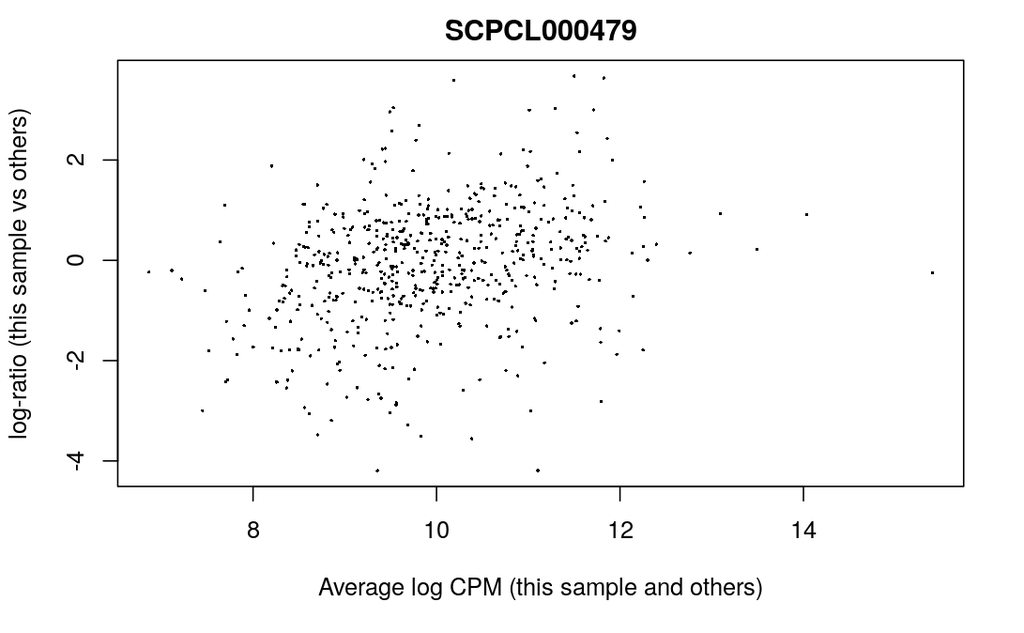

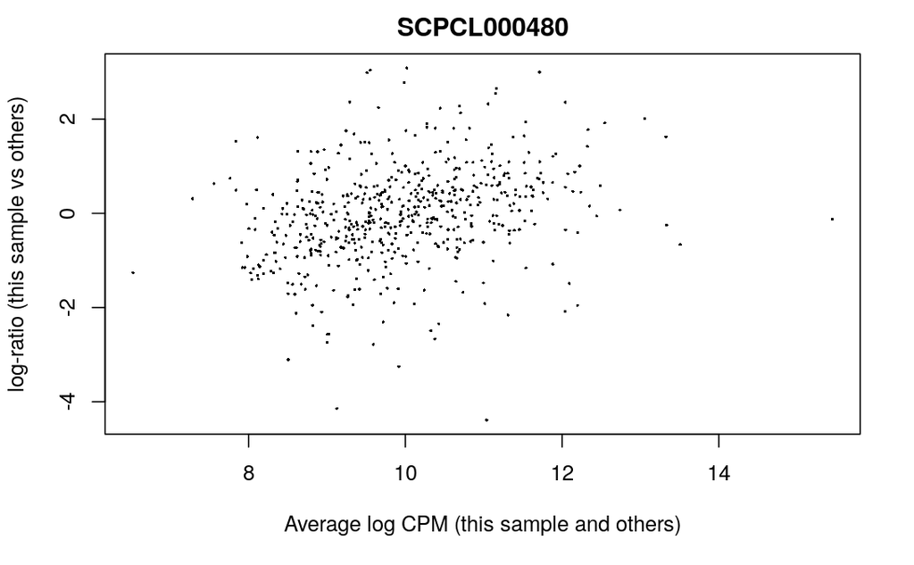

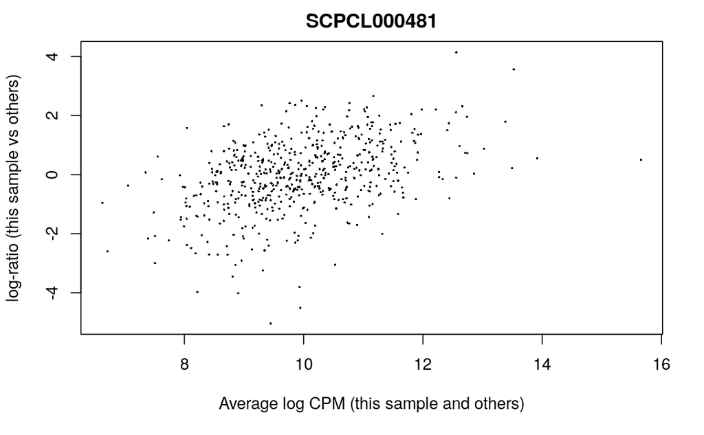

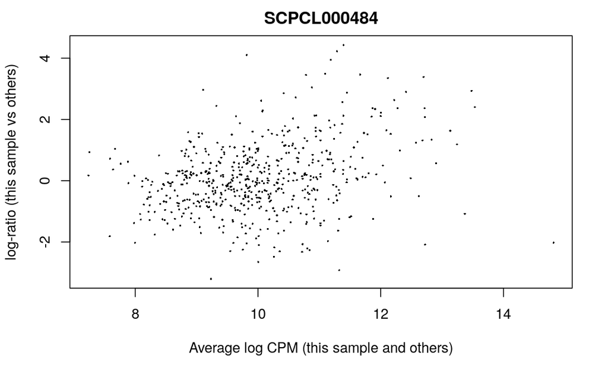

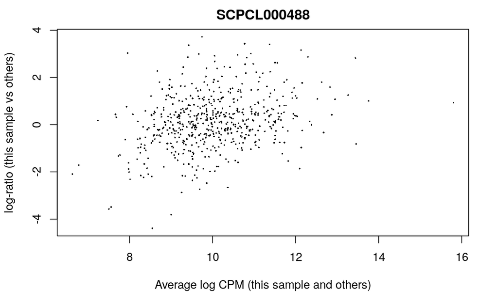

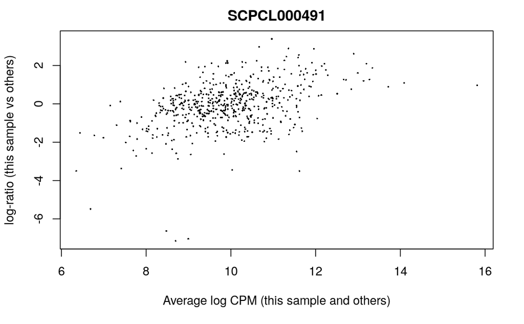

```r
# mean difference plots
purrr::walk(1:ncol(dge_list),
            ~ limma::plotMD(dge_list, column = .x))
```

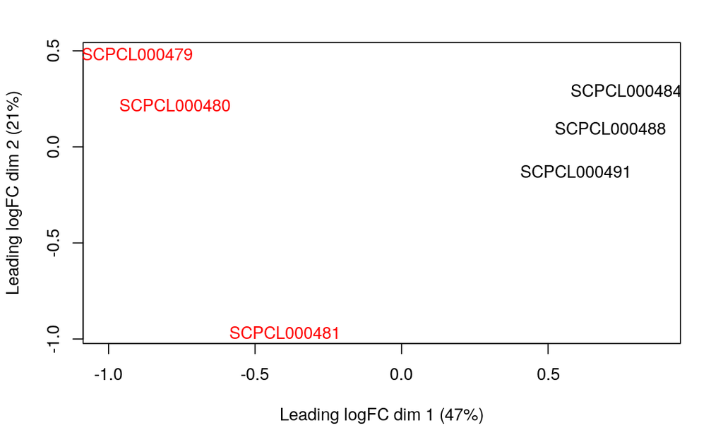

```r
# MDS scaling plot
# first compute counts per million
counts_per_million <- edgeR::cpm(dge_list, log = TRUE)

dge_list$samples <- dge_list$samples %>%
  dplyr::mutate(diagnosis_groups = dplyr::case_when(
    subdiagnosis == "Alveolar rhabdomyosarcoma" ~ "ARMS",
    subdiagnosis == "Embryonal rhabdomyosarcoma" ~ "ERMS"
  ))

limma::plotMDS(counts_per_million,
        # add some colors based on our two groups
        col = ifelse(dge_list$samples$diagnosis_groups == "ARMS", "black", "red"))
```

Let’s do some DE now!

```r
# set up design matrix to compare between ARMS and ERMS groups
design_matrix <- model.matrix(~factor(subdiagnosis),
                              dge_list$samples)
design_matrix
```

```
            (Intercept) factor(subdiagnosis)Embryonal rhabdomyosarcoma
SCPCL000479           1                                              1
SCPCL000480           1                                              1
SCPCL000481           1                                              1
SCPCL000484           1                                              0
SCPCL000488           1                                              0
SCPCL000491           1                                              0
attr(,"assign")
[1] 0 1
attr(,"contrasts")
attr(,"contrasts")$`factor(subdiagnosis)`
[1] "contr.treatment"
```

Estimate dispersions using both the quasi-likelihood(QL) dispersion and the negative binomial(NB) dispersions.

```r
# estimate NB dispersions
dge_list <- edgeR::estimateDisp(dge_list, design = design_matrix)
summary(dge_list$trended.dispersion)
```

```
   Min. 1st Qu.  Median    Mean 3rd Qu.    Max.
 0.2358  0.2627  0.2665  0.2881  0.3085  0.4846
```

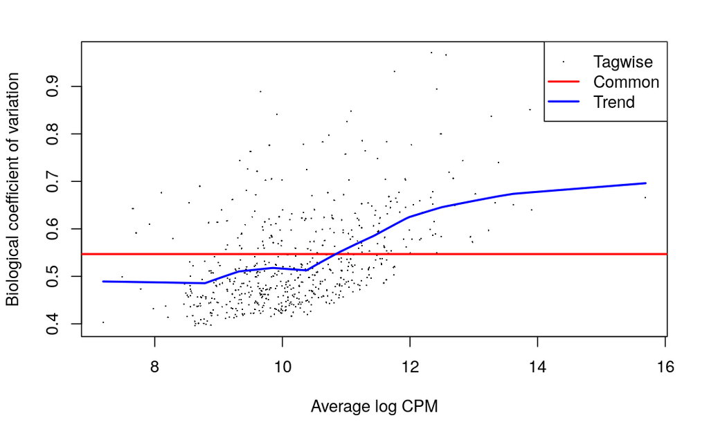

```r
edgeR::plotBCV(dge_list)
```

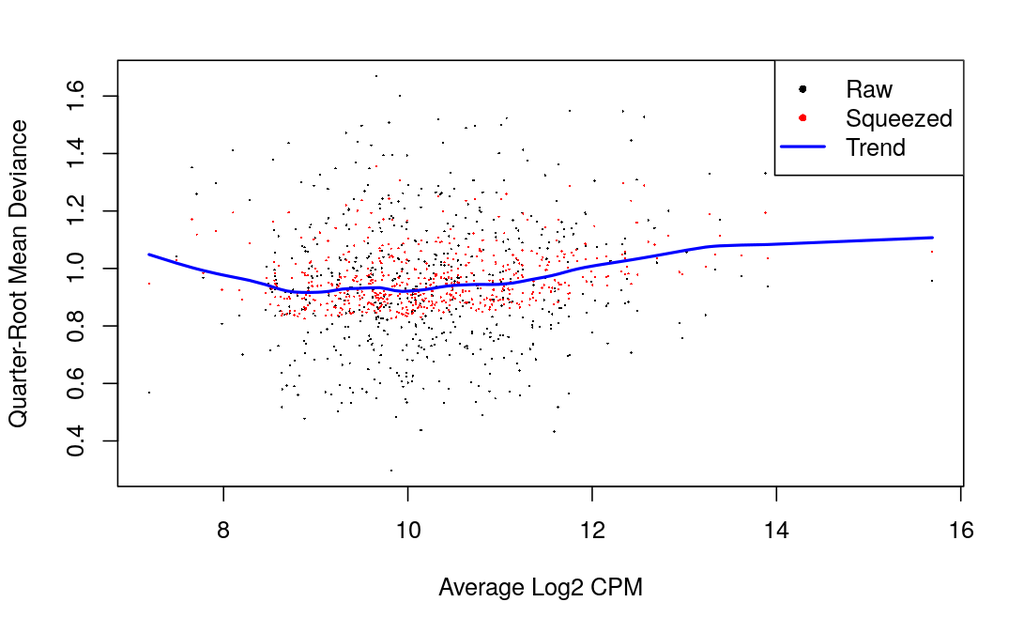

```r
# estimate the quasi-likelihood dispersions
glm_fit <- edgeR::glmQLFit(dge_list, design_matrix, robust = TRUE)
edgeR::plotQLDisp(glm_fit)
```

Test for differences using the `glmQLFTest` where differentially expressed gens are defined as those with non-zero LFC and a FDR of < 5%.

```r
results <- edgeR::glmQLFTest(glm_fit, coef = ncol(design_matrix))
summary(limma::decideTests(results))
```

```
       factor(subdiagnosis)Embryonal rhabdomyosarcoma
Down                                               30
NotSig                                            524
Up                                                 19
```

```r
edger_results <- edgeR::topTags(results, n="Inf")$table
edger_results_sig <- edger_results %>%
  dplyr::filter(FDR <= 0.05)

# print out results
edger_results_sig
```

|  | logFC | logCPM | F | PValue | FDR |
| --- | --- | --- | --- | --- | --- |
| ENSG00000107104 | -3.645749 | 10.479142 | 39.33730 | 6.478043e-05 | 0.02211737 |
| ENSG00000283563 | 3.770655 | 11.351481 | 35.37293 | 1.021915e-04 | 0.02211737 |
| ENSG00000176771 | -4.412219 | 11.098540 | 33.54053 | 1.279086e-04 | 0.02211737 |
| ENSG00000134508 | -3.045156 | 10.081182 | 31.09659 | 1.752190e-04 | 0.02211737 |
| ENSG00000134532 | -2.821677 | 10.709526 | 29.26467 | 2.246688e-04 | 0.02211737 |
| ENSG00000169372 | -2.403823 | 9.258801 | 28.38540 | 2.542072e-04 | 0.02211737 |
| ENSG00000073910 | -4.882652 | 11.699678 | 27.86201 | 2.739781e-04 | 0.02211737 |
| ENSG00000185046 | -3.977144 | 11.506504 | 26.05745 | 3.576633e-04 | 0.02211737 |
| ENSG00000156011 | 3.932718 | 11.897005 | 25.77497 | 3.733586e-04 | 0.02211737 |
| ENSG00000164330 | -3.137613 | 10.470096 | 25.55764 | 3.859925e-04 | 0.02211737 |

[output cut: 39 more lines]

### Perform differential expression with DESeq2

Let’s do the same thing, but try with DESeq2.

```r
# deseq2 requires the coldata object as a separate input
coldata_df <- as.data.frame(colData(tumor_myoblast_sce)) %>%
  dplyr::mutate(diagnosis_groups = factor(
    dplyr::case_when(
      subdiagnosis == "Alveolar rhabdomyosarcoma" ~ "ARMS",
      subdiagnosis == "Embryonal rhabdomyosarcoma" ~ "ERMS"
    ),
    levels = c("ARMS", "ERMS")
  ))

# set up the deseq object
deseq_object <- DESeq2::DESeqDataSetFromMatrix(counts(tumor_myoblast_sce),
                                               colData = coldata_df,
                                               design = ~ diagnosis_groups)
```

```r
# we get a warning if we don't use local that it can't find a model
# this could likely be due to batch effects present in the data
normalized_object <- DESeq2::varianceStabilizingTransformation(deseq_object, blind = TRUE)
```

```
-- note: fitType='parametric', but the dispersion trend was not well captured by the
   function: y = a/x + b, and a local regression fit was automatically substituted.
   specify fitType='local' or 'mean' to avoid this message next time.
```

Evaluate QC here using PCA. Here we can label by the diagnosis groups to show that the highest amount of variance is due to different diagnosis types.

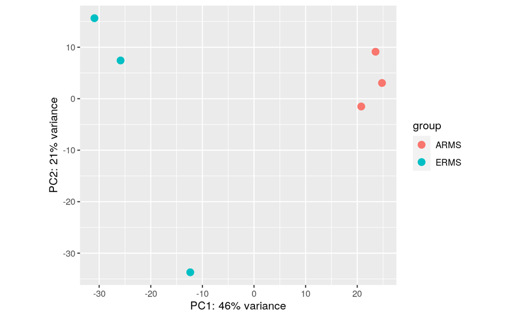

```r
DESeq2::plotPCA(normalized_object, intgroup = "diagnosis_groups")
```

We can also label by other metadata to see if there are other factors that might be related to variation.

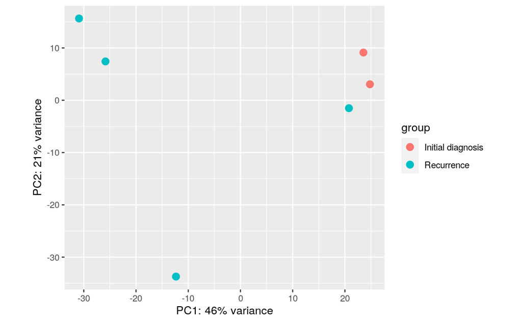

```r
DESeq2::plotPCA(normalized_object, intgroup = "disease_timing")
```

```r
# run DESeq
# use the same fit type as with rlog
deseq_object <- DESeq2::DESeq(deseq_object, fitType = 'local')
```

Next we take a look at the dispersions, we expect to see dispersions decrease as means are increasing and follow the line of best fit. Here dispersions are increasing as mean is increasing but are following the line of best fit, so not the most ideal… perhaps underlying batch effects are here and affecting this?

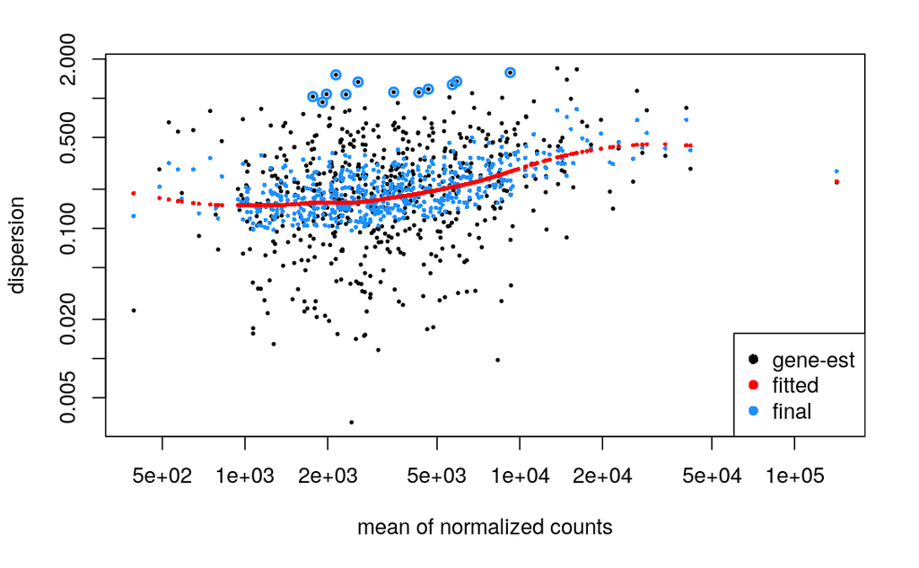

```r
plotDispEsts(deseq_object)
```

```r
deseq_results <- DESeq2::results(deseq_object, alpha = 0.05)
DESeq2::resultsNames(deseq_object)
shrink_results <- DESeq2::lfcShrink(deseq_object, res = deseq_results, coef = 2, type = "apeglm")
```

```r
# look at what actually happened when we applyed shrinkage (adjustment of large fold changes that are overestimated)
comparison_df <- data.frame(
  lfc_original = deseq_results$log2FoldChange,
  lfc_shrunken = shrink_results$log2FoldChange,
  logmean = log10(deseq_results$baseMean)
  )

ggplot(comparison_df,
       aes(x = lfc_original,
           y = lfc_shrunken,
           color = logmean)) +
  geom_point(alpha = 0.1) +
  theme_bw() +
  scale_color_viridis_c() +
  coord_cartesian(xlim = c(-10,10), ylim = c(-10,10))
```

[output not shown]

Let’s get a table of the genes that are significant.

```r
deseq_results <- shrink_results %>%
  as.data.frame() %>%
  tibble::rownames_to_column("ensembl_id")

deseq_results_sig <- deseq_results %>%
  dplyr::filter(padj <= 0.05)

deseq_results_sig
```

[output not shown]

## Evaluating the DGE Results

### Comparing methods

Before we move on, let’s compare the results between the two types of DEG analysis we did. Here we can look at the correlation between the `logFC` calculated with `edgeR` and the logFC calculated with DESeq2, which we expect to be similar. We can then see which genes are calculated as significant with each method and how they compare.

```r
edger_results <- edger_results %>%
  tibble::rownames_to_column("ensembl_id") %>%
  dplyr::select(ensembl_id, logFC, FDR) %>%
  dplyr::rename("edgeR_LogFC" = "logFC",
                "edgeR_padj" = "FDR")

combined_results <- deseq_results %>%
  dplyr::select(ensembl_id, log2FoldChange, padj) %>%
  dplyr::rename("DESeq_LogFC" = "log2FoldChange",
                "DESeq_padj" = "padj") %>%
  dplyr::inner_join(edger_results, by = c("ensembl_id")) %>%
  dplyr::mutate(
    significance = dplyr::case_when(DESeq_padj <= 0.05 & edgeR_padj > 0.05 ~ "DESeq",
                                    DESeq_padj > 0.05 & edgeR_padj <= 0.05 ~ "edgeR",
                                    DESeq_padj <= 0.05 & edgeR_padj <= 0.05 ~ "both",
                                    DESeq_padj > 0.05 & edgeR_padj > 0.05 ~ "None")
  )
```

```r
ggplot(combined_results, aes(x = DESeq_LogFC, y = edgeR_LogFC, color = significance)) +
  geom_point(alpha = 0.5) +
  theme_bw()
```

[output not shown]

### Exploring the identified differentially expressed genes

Let’s also do some initial analysis to look at what types of genes are being identified and see if what is being identified as actually up/down regulated appear to correlate back to the single cell data.

The first plot we’ll make is a volcano plot and we can label the significant genes with their gene symbols. For now, let’s use the DESeq results.

```r
deseq_df <- shrink_results %>%
  as.data.frame() %>%
  tibble::rownames_to_column("ensembl_id")

sce_rowdata_df <- rowData(tumor_myoblast_sce) %>%
  as.data.frame() %>%
  tibble::rownames_to_column("ensembl_id")

deseq_df <- deseq_df %>%
  dplyr::left_join(sce_rowdata_df, by = "ensembl_id")
```

```r
EnhancedVolcano::EnhancedVolcano(deseq_df,
                x = 'log2FoldChange', # fold change statistic to plot
                y = 'pvalue', # significance values
                lab = deseq_df$gene_symbol.SCPCL000478, # labels for points
                pCutoff = 1e-05, # The p value cutoff we will use (default)
                FCcutoff = 1, # The fold change cutoff (default)
                title = NULL, # no title
                subtitle = NULL, # or subtitle
                caption = NULL, # or caption
                labSize = 3  # smaller labels
                ) +
  # change the overall theme
  theme_classic() +
  # move the legend to the bottom
  theme(legend.position = "bottom")
```

[output not shown]

Let’s make some UMAPs where we plot a gene that’s identified to be differentially expressed in a given cell type and see what the expression of that gene is across samples.

```r
# add column to colData with expression of gene of interest
# here we will actually put all of the significant genes so then we can plot any of them
sig_expressed_genes <- deseq_df %>%
  dplyr::filter(pvalue < 1e-5,
                abs(log2FoldChange) > 2) %>%
  dplyr::pull(ensembl_id)

sig_genes_counts <- logcounts(combined_sce[sig_expressed_genes,]) %>%
  as.matrix() %>%
  t() %>%
  as.data.frame() %>%
  dplyr::mutate(cell_id = colnames(combined_sce))

combined_coldata_df <- as.data.frame(colData(combined_sce)) %>%
  dplyr::left_join(sig_genes_counts, by = "cell_id")

# add back modified coldata containing gene expression for sig genes
colData(combined_sce) <- DataFrame(combined_coldata_df, row.names = combined_coldata_df$cell_id)
```

```r
# filter to just myoblast cells and remove any NA's before plotting
myoblast_combined_sce <- combined_sce[, which(combined_sce$celltype_broad == "Tumor_Myoblast")]

# first look at just ARMS vs. ERMS
scater::plotReducedDim(myoblast_combined_sce,
                       dimred = "fastmnn_UMAP",
                       colour_by = "ENSG00000134532", #SOX5
                       point_size= 0.5,
                       point_alpha = 0.4) +
  facet_wrap(~ myoblast_combined_sce$subdiagnosis, nrow = 3)
```

```r
# now let's look at the same gene across each sample
scater::plotReducedDim(myoblast_combined_sce,
                       dimred = "fastmnn_UMAP",
                       colour_by = "ENSG00000134532", #SOX5
                       point_size= 0.5,
                       point_alpha = 0.4) +
  facet_wrap(~ myoblast_combined_sce$subdiagnosis + myoblast_combined_sce$batch, nrow = 3, dir = 'v')
```

What about some genes that are differentially expressed in only `DESeq` but not `edgeR`?

```r
# pick out the top genes that are identified as DE in only DESeq and plot those
combined_results %>%
  dplyr::filter(significance == "DESeq") %>%
  dplyr::arrange(DESeq_LogFC)
```

```r
# top downregulated gene
scater::plotReducedDim(myoblast_combined_sce,
                       dimred = "fastmnn_UMAP",
                       colour_by = "ENSG00000182197", #EXT1
                       point_size= 0.5,
                       point_alpha = 0.4) +
  facet_wrap(~ myoblast_combined_sce$batch + myoblast_combined_sce$subdiagnosis, nrow = 3)
```

```r
scater::plotReducedDim(myoblast_combined_sce,
                       dimred = "fastmnn_UMAP",
                       colour_by = "ENSG00000161671", #EXT1
                       point_size= 0.5,
                       point_alpha = 0.4) +
  facet_wrap(~ myoblast_combined_sce$batch + myoblast_combined_sce$subdiagnosis, nrow = 3)
```

## Some conclusions and future thoughts

- The RMS dataset seems like a good dataset we can use for integration
- We probably don’t want to blindly use all libraries that we have currently used for integration, but should use the 6 samples that have varying sub diagnosis and also share similar cell types
- Here we did some preliminary comparisons using `edgeR` and `DESeq`, but we probably don’t need to actually do that in class, we should pick one and show how you would do the analysis first to look at one cell type between experimental conditions and then across multiple cell types/ labels
- `edgeR` is a bit more conservative in its approach to identify differentially expressed genes